# Risk Factor Analysis

## Outcome Variable

**Outcome Variable:** co_occurence

## Predictor Variables

**Intervention Variable:** ever_co06

**Adjustment Set:**

- sex
- arm
- brthmon
- single
- hhwealth_quart
- W_mage
- W_mhtcm
- W_meducyrs
- W_feducyrs
- delta_brthmon
- delta_single
- delta_hhwealth_quart
- delta_W_mage
- delta_W_mhtcm
- delta_W_meducyrs
- delta_W_feducyrs

## Stratifying Variables

The analysis was stratified on these variable(s):

- studyid
- country

## Data Summary

| studyid | country | ever_co06 | co_occurence | n_cell | n |
| --- | --- | --- | --- | --- | --- |
| CMC-V-BCS-2002 | INDIA | 0 | 0 | 319 | 366 |
| CMC-V-BCS-2002 | INDIA | 0 | 1 | 16 | 366 |
| CMC-V-BCS-2002 | INDIA | 1 | 0 | 25 | 366 |
| CMC-V-BCS-2002 | INDIA | 1 | 1 | 6 | 366 |
| CMIN | BANGLADESH | 0 | 0 | 204 | 237 |
| CMIN | BANGLADESH | 0 | 1 | 21 | 237 |
| CMIN | BANGLADESH | 1 | 0 | 7 | 237 |
| CMIN | BANGLADESH | 1 | 1 | 5 | 237 |
| COHORTS | GUATEMALA | 0 | 0 | 723 | 774 |
| COHORTS | GUATEMALA | 0 | 1 | 35 | 774 |
| COHORTS | GUATEMALA | 1 | 0 | 13 | 774 |
| COHORTS | GUATEMALA | 1 | 1 | 3 | 774 |
| COHORTS | PHILIPPINES | 0 | 0 | 2265 | 2487 |
| COHORTS | PHILIPPINES | 0 | 1 | 168 | 2487 |
| COHORTS | PHILIPPINES | 1 | 0 | 35 | 2487 |
| COHORTS | PHILIPPINES | 1 | 1 | 19 | 2487 |
| CONTENT | PERU | 0 | 0 | 200 | 200 |
| CONTENT | PERU | 0 | 1 | 0 | 200 |
| CONTENT | PERU | 1 | 0 | 0 | 200 |
| CONTENT | PERU | 1 | 1 | 0 | 200 |
| EE | PAKISTAN | 0 | 0 | 241 | 346 |
| EE | PAKISTAN | 0 | 1 | 50 | 346 |
| EE | PAKISTAN | 1 | 0 | 31 | 346 |
| EE | PAKISTAN | 1 | 1 | 24 | 346 |
| GMS-Nepal | NEPAL | 0 | 0 | 469 | 550 |
| GMS-Nepal | NEPAL | 0 | 1 | 52 | 550 |
| GMS-Nepal | NEPAL | 1 | 0 | 21 | 550 |
| GMS-Nepal | NEPAL | 1 | 1 | 8 | 550 |
| IRC | INDIA | 0 | 0 | 362 | 404 |
| IRC | INDIA | 0 | 1 | 20 | 404 |

[output cut: 78 more lines]

The following strata were considered:

- studyid: CMC-V-BCS-2002, country: INDIA
- studyid: CMIN, country: BANGLADESH
- studyid: COHORTS, country: GUATEMALA
- studyid: COHORTS, country: PHILIPPINES
- studyid: CONTENT, country: PERU
- studyid: EE, country: PAKISTAN
- studyid: GMS-Nepal, country: NEPAL
- studyid: IRC, country: INDIA
- studyid: JiVitA-4, country: BANGLADESH
- studyid: Keneba, country: GAMBIA
- studyid: LCNI-5, country: MALAWI
- studyid: MAL-ED, country: BANGLADESH
- studyid: MAL-ED, country: BRAZIL
- studyid: MAL-ED, country: INDIA
- studyid: MAL-ED, country: NEPAL
- studyid: MAL-ED, country: PERU
- studyid: MAL-ED, country: SOUTH AFRICA
- studyid: MAL-ED, country: TANZANIA, UNITED REPUBLIC OF
- studyid: NIH-Birth, country: BANGLADESH
- studyid: NIH-Crypto, country: BANGLADESH
- studyid: PROBIT, country: BELARUS
- studyid: PROVIDE, country: BANGLADESH
- studyid: ResPak, country: PAKISTAN
- studyid: SAS-CompFeed, country: INDIA
- studyid: SAS-FoodSuppl, country: INDIA
- studyid: TanzaniaChild2, country: TANZANIA, UNITED REPUBLIC OF
- studyid: ZVITAMBO, country: ZIMBABWE

### Dropped Strata

Some strata were dropped due to rare outcomes:

- studyid: COHORTS, country: GUATEMALA
- studyid: CONTENT, country: PERU
- studyid: LCNI-5, country: MALAWI
- studyid: MAL-ED, country: BANGLADESH
- studyid: MAL-ED, country: BRAZIL
- studyid: MAL-ED, country: NEPAL
- studyid: MAL-ED, country: PERU
- studyid: MAL-ED, country: SOUTH AFRICA
- studyid: MAL-ED, country: TANZANIA, UNITED REPUBLIC OF
- studyid: PROBIT, country: BELARUS
- studyid: ResPak, country: PAKISTAN
- studyid: TanzaniaChild2, country: TANZANIA, UNITED REPUBLIC OF

## Methods Detail

We’re interested in the causal parameters $E[Y_a]$ for all values of $a \in \mathcal{A}$. These parameters represent the mean outcome if, possibly contrary to fact, we intervened to set all units to have $A=a$. Under the randomization and positivity assumptions, these are identified by the statistical parameters $\psi_a=E_W[E_{Y|A,W}(Y|A=a,W)]$. In addition, we’re interested in the mean of $Y$, $E[Y]$ under no intervention (the observed mean). We will estimate these parameters by using SuperLearner to fit the relevant likelihood factors – $E_{Y|A,W}(Y|A=a,W)$ and $p(A=a|W)$, and then updating our likelihood fit using a joint TMLE.

For unadjusted analyses ($W=\{\}$), initial likelihoods were estimated using Lrnr_glm to estimate the simple $E(Y|A)$ and Lrnr_mean to estimate $p(A)$. For adjusted analyses, a small library containing Lrnr_glmnet, Lrnr_xgboost, and Lrnr_mean was used.

Having estimated these parameters, we will then use the delta method to estimate relative risks and attributable risks relative to a prespecified baseline level of $A$.

# Results Detail

## Results Plots

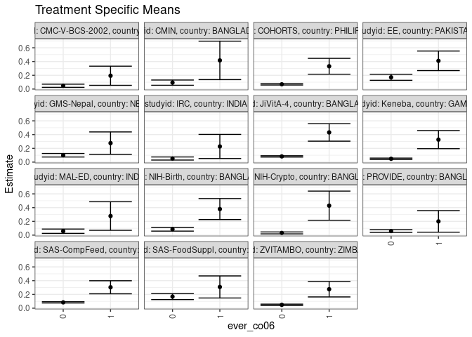

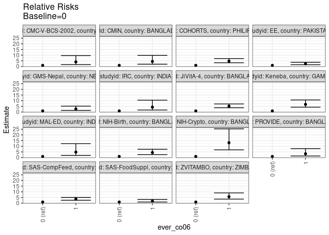

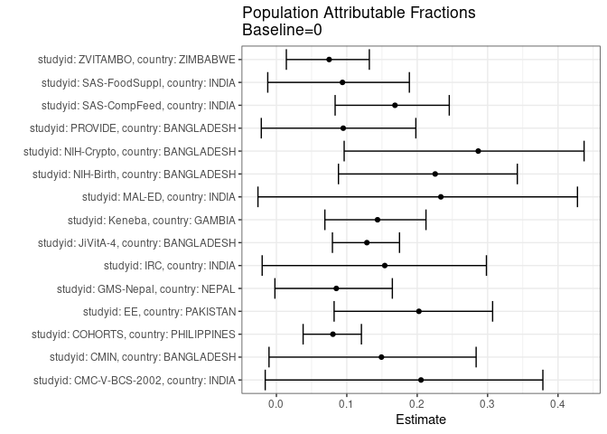

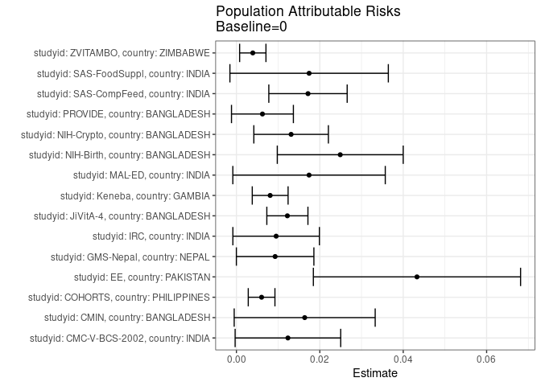

## Results Table

### Parameter: TSM

| studyid | country | intervention_level | baseline_level | estimate | ci_lower | ci_upper |
| --- | --- | --- | --- | --- | --- | --- |
| CMC-V-BCS-2002 | INDIA | 0 | NA | 0.0477612 | 0.0248931 | 0.0706293 |
| CMC-V-BCS-2002 | INDIA | 1 | NA | 0.1935484 | 0.0542823 | 0.3328144 |
| CMIN | BANGLADESH | 0 | NA | 0.0933333 | 0.0552428 | 0.1314239 |
| CMIN | BANGLADESH | 1 | NA | 0.4166667 | 0.1371367 | 0.6961967 |
| COHORTS | PHILIPPINES | 0 | NA | 0.0691534 | 0.0590417 | 0.0792650 |
| COHORTS | PHILIPPINES | 1 | NA | 0.3311314 | 0.2159134 | 0.4463495 |
| EE | PAKISTAN | 0 | NA | 0.1705750 | 0.1269274 | 0.2142226 |
| EE | PAKISTAN | 1 | NA | 0.4104552 | 0.2684045 | 0.5525058 |
| GMS-Nepal | NEPAL | 0 | NA | 0.0998081 | 0.0740463 | 0.1255698 |
| GMS-Nepal | NEPAL | 1 | NA | 0.2758621 | 0.1130446 | 0.4386795 |
| IRC | INDIA | 0 | NA | 0.0523560 | 0.0299915 | 0.0747206 |
| IRC | INDIA | 1 | NA | 0.2272727 | 0.0519405 | 0.4026049 |
| JiVitA-4 | BANGLADESH | 0 | NA | 0.0828502 | 0.0737635 | 0.0919370 |
| JiVitA-4 | BANGLADESH | 1 | NA | 0.4314117 | 0.3043338 | 0.5584896 |
| Keneba | GAMBIA | 0 | NA | 0.0482440 | 0.0381292 | 0.0583588 |
| Keneba | GAMBIA | 1 | NA | 0.3264472 | 0.1949300 | 0.4579645 |
| MAL-ED | INDIA | 0 | NA | 0.0571429 | 0.0256801 | 0.0886056 |
| MAL-ED | INDIA | 1 | NA | 0.2777778 | 0.0704056 | 0.4851500 |
| NIH-Birth | BANGLADESH | 0 | NA | 0.0854926 | 0.0587505 | 0.1122348 |
| NIH-Birth | BANGLADESH | 1 | NA | 0.3790935 | 0.2265610 | 0.5316260 |
| NIH-Crypto | BANGLADESH | 0 | NA | 0.0326264 | 0.0185516 | 0.0467012 |
| NIH-Crypto | BANGLADESH | 1 | NA | 0.4285714 | 0.2167481 | 0.6403948 |
| PROVIDE | BANGLADESH | 0 | NA | 0.0594796 | 0.0394758 | 0.0794833 |
| PROVIDE | BANGLADESH | 1 | NA | 0.2000000 | 0.0430634 | 0.3569366 |
| SAS-CompFeed | INDIA | 0 | NA | 0.0847466 | 0.0756861 | 0.0938071 |
| SAS-CompFeed | INDIA | 1 | NA | 0.3041361 | 0.2092013 | 0.3990708 |
| SAS-FoodSuppl | INDIA | 0 | NA | 0.1683235 | 0.1252561 | 0.2113910 |
| SAS-FoodSuppl | INDIA | 1 | NA | 0.3087267 | 0.1483337 | 0.4691197 |
| ZVITAMBO | ZIMBABWE | 0 | NA | 0.0484555 | 0.0380125 | 0.0588984 |
| ZVITAMBO | ZIMBABWE | 1 | NA | 0.2758621 | 0.1635093 | 0.3882148 |

### Parameter: E(Y)

| studyid | country | intervention_level | baseline_level | estimate | ci_lower | ci_upper |
| --- | --- | --- | --- | --- | --- | --- |
| CMC-V-BCS-2002 | INDIA | NA | NA | 0.0601093 | 0.0357249 | 0.0844936 |
| CMIN | BANGLADESH | NA | NA | 0.1097046 | 0.0698323 | 0.1495770 |
| COHORTS | PHILIPPINES | NA | NA | 0.0751910 | 0.0648251 | 0.0855569 |
| EE | PAKISTAN | NA | NA | 0.2138728 | 0.1706052 | 0.2571404 |
| GMS-Nepal | NEPAL | NA | NA | 0.1090909 | 0.0830130 | 0.1351688 |
| IRC | INDIA | NA | NA | 0.0618812 | 0.0383576 | 0.0854048 |
| JiVitA-4 | BANGLADESH | NA | NA | 0.0950696 | 0.0850280 | 0.1051113 |
| Keneba | GAMBIA | NA | NA | 0.0563380 | 0.0456085 | 0.0670675 |
| MAL-ED | INDIA | NA | NA | 0.0745614 | 0.0403897 | 0.1087331 |
| NIH-Birth | BANGLADESH | NA | NA | 0.1103896 | 0.0817833 | 0.1389959 |
| NIH-Crypto | BANGLADESH | NA | NA | 0.0457413 | 0.0294659 | 0.0620168 |
| PROVIDE | BANGLADESH | NA | NA | 0.0657194 | 0.0452330 | 0.0862057 |
| SAS-CompFeed | INDIA | NA | NA | 0.1019108 | 0.0902026 | 0.1136190 |
| SAS-FoodSuppl | INDIA | NA | NA | 0.1857585 | 0.1432798 | 0.2282372 |
| ZVITAMBO | ZIMBABWE | NA | NA | 0.0523810 | 0.0417242 | 0.0630377 |

### Parameter: RR

| studyid | country | intervention_level | baseline_level | estimate | ci_lower | ci_upper |
| --- | --- | --- | --- | --- | --- | --- |
| CMC-V-BCS-2002 | INDIA | 0 | 0 | 1.000000 | 1.000000 | 1.000000 |
| CMC-V-BCS-2002 | INDIA | 1 | 0 | 4.052419 | 1.707496 | 9.617651 |
| CMIN | BANGLADESH | 0 | 0 | 1.000000 | 1.000000 | 1.000000 |
| CMIN | BANGLADESH | 1 | 0 | 4.464286 | 2.035729 | 9.790027 |
| COHORTS | PHILIPPINES | 0 | 0 | 1.000000 | 1.000000 | 1.000000 |
| COHORTS | PHILIPPINES | 1 | 0 | 4.788364 | 3.283415 | 6.983105 |
| EE | PAKISTAN | 0 | 0 | 1.000000 | 1.000000 | 1.000000 |
| EE | PAKISTAN | 1 | 0 | 2.406303 | 1.564081 | 3.702042 |
| GMS-Nepal | NEPAL | 0 | 0 | 1.000000 | 1.000000 | 1.000000 |
| GMS-Nepal | NEPAL | 1 | 0 | 2.763926 | 1.451311 | 5.263712 |
| IRC | INDIA | 0 | 0 | 1.000000 | 1.000000 | 1.000000 |
| IRC | INDIA | 1 | 0 | 4.340909 | 1.797246 | 10.484651 |
| JiVitA-4 | BANGLADESH | 0 | 0 | 1.000000 | 1.000000 | 1.000000 |
| JiVitA-4 | BANGLADESH | 1 | 0 | 5.207126 | 3.802560 | 7.130504 |
| Keneba | GAMBIA | 0 | 0 | 1.000000 | 1.000000 | 1.000000 |
| Keneba | GAMBIA | 1 | 0 | 6.766587 | 4.298784 | 10.651082 |
| MAL-ED | INDIA | 0 | 0 | 1.000000 | 1.000000 | 1.000000 |
| MAL-ED | INDIA | 1 | 0 | 4.861111 | 1.922538 | 12.291252 |
| NIH-Birth | BANGLADESH | 0 | 0 | 1.000000 | 1.000000 | 1.000000 |
| NIH-Birth | BANGLADESH | 1 | 0 | 4.434225 | 2.663948 | 7.380905 |
| NIH-Crypto | BANGLADESH | 0 | 0 | 1.000000 | 1.000000 | 1.000000 |
| NIH-Crypto | BANGLADESH | 1 | 0 | 13.135714 | 6.816156 | 25.314412 |
| PROVIDE | BANGLADESH | 0 | 0 | 1.000000 | 1.000000 | 1.000000 |
| PROVIDE | BANGLADESH | 1 | 0 | 3.362500 | 1.431850 | 7.896362 |
| SAS-CompFeed | INDIA | 0 | 0 | 1.000000 | 1.000000 | 1.000000 |
| SAS-CompFeed | INDIA | 1 | 0 | 3.588771 | 2.568750 | 5.013831 |
| SAS-FoodSuppl | INDIA | 0 | 0 | 1.000000 | 1.000000 | 1.000000 |
| SAS-FoodSuppl | INDIA | 1 | 0 | 1.834127 | 1.030354 | 3.264918 |
| ZVITAMBO | ZIMBABWE | 0 | 0 | 1.000000 | 1.000000 | 1.000000 |
| ZVITAMBO | ZIMBABWE | 1 | 0 | 5.693103 | 3.591141 | 9.025384 |

### Parameter: PAR

| studyid | country | intervention_level | baseline_level | estimate | ci_lower | ci_upper |
| --- | --- | --- | --- | --- | --- | --- |
| CMC-V-BCS-2002 | INDIA | 0 | NA | 0.0123481 | -0.0003102 | 0.0250064 |
| CMIN | BANGLADESH | 0 | NA | 0.0163713 | -0.0005355 | 0.0332781 |
| COHORTS | PHILIPPINES | 0 | NA | 0.0060376 | 0.0028391 | 0.0092362 |
| EE | PAKISTAN | 0 | NA | 0.0432978 | 0.0184512 | 0.0681445 |
| GMS-Nepal | NEPAL | 0 | NA | 0.0092828 | -0.0000111 | 0.0185768 |
| IRC | INDIA | 0 | NA | 0.0095252 | -0.0008508 | 0.0199011 |
| JiVitA-4 | BANGLADESH | 0 | NA | 0.0122194 | 0.0072904 | 0.0171484 |
| Keneba | GAMBIA | 0 | NA | 0.0080940 | 0.0037990 | 0.0123890 |
| MAL-ED | INDIA | 0 | NA | 0.0174185 | -0.0008598 | 0.0356969 |
| NIH-Birth | BANGLADESH | 0 | NA | 0.0248970 | 0.0098000 | 0.0399940 |
| NIH-Crypto | BANGLADESH | 0 | NA | 0.0131149 | 0.0041754 | 0.0220544 |
| PROVIDE | BANGLADESH | 0 | NA | 0.0062398 | -0.0011818 | 0.0136614 |
| SAS-CompFeed | INDIA | 0 | NA | 0.0171642 | 0.0077683 | 0.0265602 |
| SAS-FoodSuppl | INDIA | 0 | NA | 0.0174350 | -0.0015610 | 0.0364310 |
| ZVITAMBO | ZIMBABWE | 0 | NA | 0.0039255 | 0.0007688 | 0.0070822 |

### Parameter: PAF

| studyid | country | intervention_level | baseline_level | estimate | ci_lower | ci_upper |
| --- | --- | --- | --- | --- | --- | --- |
| CMC-V-BCS-2002 | INDIA | 0 | NA | 0.2054274 | -0.0158579 | 0.3785099 |
| CMIN | BANGLADESH | 0 | NA | 0.1492308 | -0.0104896 | 0.2837053 |
| COHORTS | PHILIPPINES | 0 | NA | 0.0802974 | 0.0379656 | 0.1207664 |
| EE | PAKISTAN | 0 | NA | 0.2024466 | 0.0819760 | 0.3071082 |
| GMS-Nepal | NEPAL | 0 | NA | 0.0850928 | -0.0021055 | 0.1647035 |
| IRC | INDIA | 0 | NA | 0.1539267 | -0.0202056 | 0.2983375 |
| JiVitA-4 | BANGLADESH | 0 | NA | 0.1285310 | 0.0795920 | 0.1748679 |
| Keneba | GAMBIA | 0 | NA | 0.1436689 | 0.0688458 | 0.2124796 |
| MAL-ED | INDIA | 0 | NA | 0.2336134 | -0.0261772 | 0.4276346 |
| NIH-Birth | BANGLADESH | 0 | NA | 0.2255375 | 0.0881700 | 0.3422105 |
| NIH-Crypto | BANGLADESH | 0 | NA | 0.2867188 | 0.0962517 | 0.4370445 |
| PROVIDE | BANGLADESH | 0 | NA | 0.0949462 | -0.0214436 | 0.1980739 |
| SAS-CompFeed | INDIA | 0 | NA | 0.1684241 | 0.0834131 | 0.2455506 |
| SAS-FoodSuppl | INDIA | 0 | NA | 0.0938583 | -0.0122789 | 0.1888671 |
| ZVITAMBO | ZIMBABWE | 0 | NA | 0.0749408 | 0.0141286 | 0.1320019 |